# Data Science Capstone Project - Final project submission

2022-11-20

## Introduction

This is an app that can be used as a text prediction application based on input provided by user. We have used language modelling algorithm that uses a corpus of english language as base for predictions.

The corpus is taken from the following three sources:

- Blogs
- News
- Twitter

## Methodology

A random sample is taken from the corpus. A combination of the following approaches is used in the app to provide suggestions:

- Katz Backoff
- Kneser Ney
- Good Turing

The mix of the above approaches is used to derive a relavance score. Higher relevance score signifies higher accuracy of predictions.

## Functionalities

1. In the text input box enter the sentense for which next word should be predicted.
2. You can enter one word or multiple words to get the predictions.
3. Select the radio box to access top 3/5/10/25 predictions.
4. Hit predict to get the list of predictions.

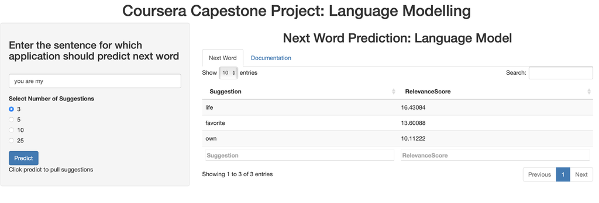

sample application

## Source

This application is using [reactive expressions](https://shiny.rstudio.com/tutorial/written-tutorial/lesson6/) for better user experience, and auto update.

The application can be found @ [ShinyApps.io](https://kamolcht.shinyapps.io/Jhu_DS_Final-Project-Submission/).

This presentation is hosted by [RPubs](http://rpubs.com/ktangsri/jhu_ds_final_project)

Source can be found @ [GitHub](https://github.com/kamolchanokTa/Jhu_DS_Final-Project-Submission)